# Project 2

**Group members: Fabiana Latorre, Oliver Benton Javier, Ernesto Canales, and Nikolaj Plagborg-Moller.**

Our dataset can be found at ‘http://catalog.data.gov/dataset/international-food-security’.

We load the data-table into a variable named ‘df’ and display a subset of the data (as an exception, we used the ‘head’ function instead of ‘tbl_df’, since ‘tbl_df’ does not display every column).

```r
source('../01 Data/Fetching_data.R', echo=TRUE)
```

```
##
## > df <- data.frame(eval(parse(text = substring(getURL(URLencode("http://129.152.144.84:5001/rest/native/?query=\"select * from MyCSV\""),
## +     httph .... [TRUNCATED]
##
## > head(df)
##   COUNTRY            COMMODITY
## 1 Algeria Total Grains/Cereals
## 2 Algeria        Economic Data
## 3 Algeria        Economic Data
## 4 Algeria        Economic Data
## 5 Algeria        Economic Data
## 6 Algeria        Economic Data
##                                                ITEM           UNIT YEAR
## 1                               Production Quantity        1000 MT 1988
## 2           Gross Domestic Product, constant prices Percent change 1988
## 3                           GDP (constant 2005 US$)        Million 1988
## 4 Imports of goods and services (constant 2005 US$)        Million 1988
## 5 Exports of goods and services (constant 2005 US$)        Million 1988
## 6       WB GDP (constant 2005 US$) / FAO population       $/Person 1988
##   AMOUNT
## 1   1038
## 2     -2
## 3  63445
## 4  17989
## 5  26525
## 6   2640
```

A challenge with our data is that the attributes of each country are separated into many different rows. We therefore thought of using the ‘spread’ functionality to gather attributes on different rows into separate columns in the same row. We chose the year 2005, and the attributes ‘Total Food Aid’ and ‘Total Population’. We arranged the data by descending population.

```r
source('../02 Data Wrangling/Wrangling1.R', echo=TRUE)
```

```
##
## > Wrangling1 <- df %>% filter(YEAR == 2005, COMMODITY ==
## +     "Population" | (COMMODITY == "Food Aid" & ITEM == "Total")) %>%
## +     select(COUNTRY, .... [TRUNCATED]
##
## > Wrangling1
##    COUNTRY Food Aid Population
## 1    India      167       1140
## 2  Nigeria       23        140
## 3  Vietnam        0         83
## 4    Egypt       13         74
## 5  DRCongo      107         57
## 6    Sudan     1073         38
## 7    Kenya      174         36
## 8  Algeria       38         33
```

[output cut: 36 more lines]

One thing we noticed when using the ‘spread’ functionality to reshape the data, is that it creates a column name with a whitespace between ‘Food’ and ‘Aid’. Unfortunately, many other functions cannot read whitespace, not even the ‘rename’ function, so it is very limited what you can do with this column, since other functions do not recognize the column name. We therefore cannot use the ‘Food Aid’ column in a ggplot, so instead we took the opportunity to try the 3D-plotting package, since it can receive column numbers instead of names. It might not make that much sense to plot this data in 3D, but we did it to experiment with the 3D-package.

```r
source('../03 Visualizations/Visualization1.R', echo=TRUE)
```

```
##
## > require("scatterplot3d")
```

```
##
## > scatterplot3d(Wrangling1[1:3], xlab = "Countries",
## +     ylab = "Food Aid (grain equiv. 1000 MT)", zlab = "Population (million)",
## +     pch = 1, h .... [TRUNCATED]
```

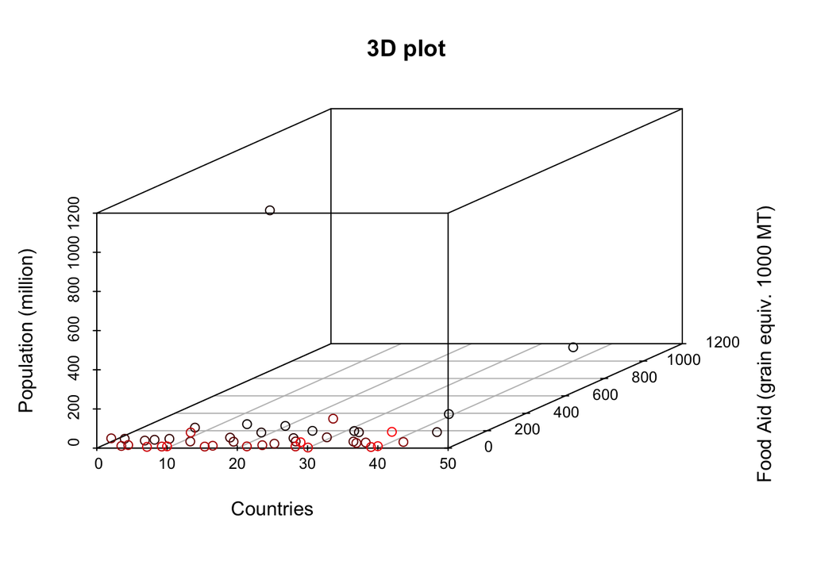

Country names are converted to numbers, so it appears that the 3D-plot package is supposed to receive only numerical data. Comparing the 3D-plot with the data table, we can identify India and Sudan as the two outliers with respect to population size and amount of aid received.

For the next data wrangling, we are comparing the amount of different kinds of aid given to three countries over a time period of 4 years. The data was arranged according to country, year, and item type respectively.

```r
source('../02 Data Wrangling/Wrangling2.R', echo=TRUE)
```

```
##
## > Wrangling2 <- df %>% filter(COUNTRY == "Angola" |
## +     COUNTRY == "Chad" | COUNTRY == "Gambia", COMMODITY == "Food Aid",
## +     between(YEAR, 2000 .... [TRUNCATED]
##
## > Wrangling2
##    COUNTRY YEAR                ITEM                 UNIT AMOUNT
## 1   Angola 2000     Cereal Food Aid Grain Equiv. 1000 MT    256
## 2   Angola 2000 Non-Cereal Food Aid Grain Equiv. 1000 MT     88
## 3   Angola 2000               Total Grain Equiv. 1000 MT    344
## 4   Angola 2001     Cereal Food Aid Grain Equiv. 1000 MT    163
## 5   Angola 2001 Non-Cereal Food Aid Grain Equiv. 1000 MT     45
## 6   Angola 2001               Total Grain Equiv. 1000 MT    208
## 7   Angola 2002     Cereal Food Aid Grain Equiv. 1000 MT    241
## 8   Angola 2002 Non-Cereal Food Aid Grain Equiv. 1000 MT     57
```

[output cut: 28 more lines]

The data is visualized below using ggplot.

```r
source('../03 Visualizations/Visualization2.R', echo=TRUE)
```

```
##
## > ggplot(Wrangling2, aes(x = YEAR, y = AMOUNT)) + geom_point(aes(color = COUNTRY)) +
## +     facet_wrap(~ITEM)
```

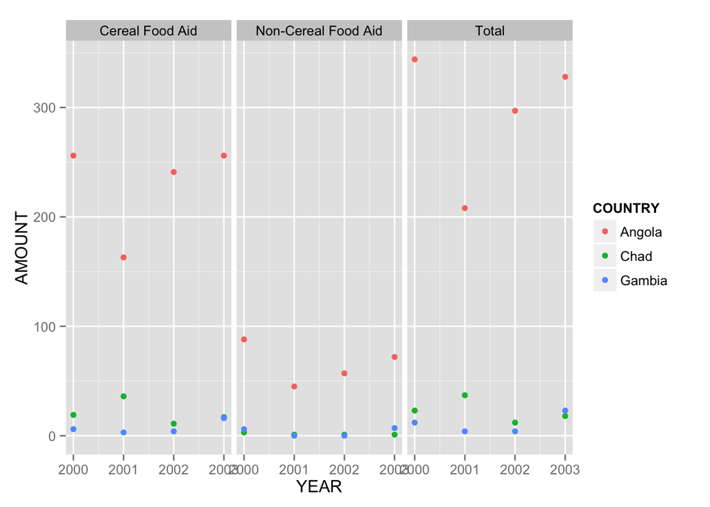

Our next data wrangling filters the rows that include total food aid, and groups the rows by year. We used summarise to calculate the total aid received by all countries in the set for each year.

```r
source('../02 Data Wrangling/Wrangling3.R', echo=TRUE)
```

```
##
## > Wrangling3 <- df %>% filter(COMMODITY == "Food Aid" &
## +     ITEM == "Total") %>% group_by(YEAR) %>% summarise(Total_Aid = sum(AMOUNT))
##
## > Wrangling3
## Source: local data frame [25 x 2]
##
##    YEAR Total_Aid
## 1  1988      7558
## 2  1989      5765
## 3  1990      5899
## 4  1991      6274
## 5  1992      6702
## 6  1993      6583
## 7  1994      6380
## 8  1995      4986
## 9  1996      3698
## 10 1997      3198
## ..  ...       ...
```

We plot the total aid received by all countries each year over time.

```r
source('../03 Visualizations/Visualization3.R', echo=TRUE)
```

```
##
## > ggplot(Wrangling3, aes(x = YEAR, y = Total_Aid)) +
## +     geom_line()
```

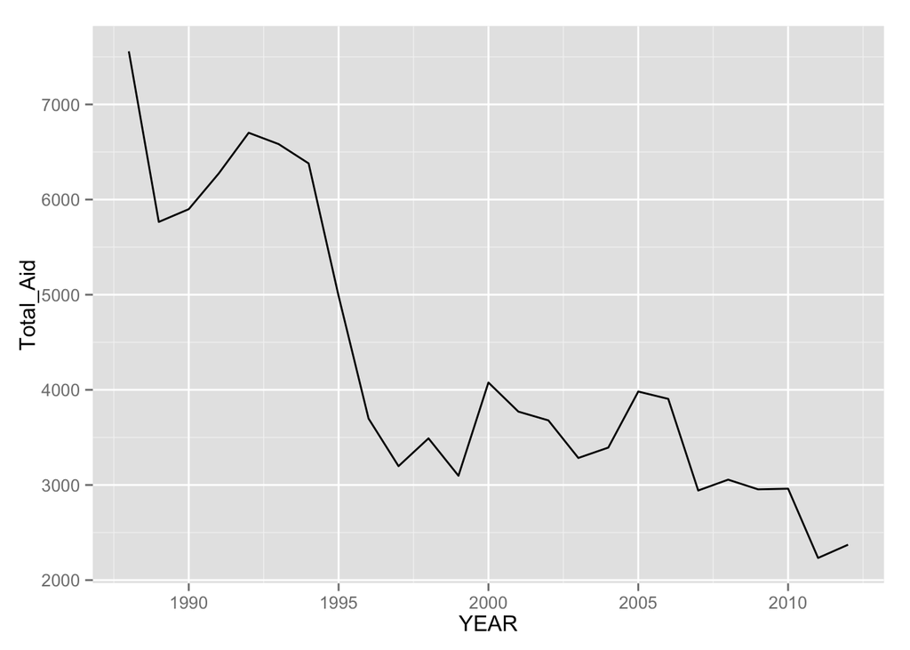

We were surprised to see that the total amount of aid received has declined considerably throughout time. Maybe the countries are better off now than they used to be and therefore need less aid.